# Project ST563

Constantino Raptis

2025-03-20

### Read in the Data

- I’m doing my PhD in Textile Technology Management (TTM) for the Wilson College of Textiles and I was trying to find something from the textile industry. I found a great data set from UCI Machine Learning Repository - https://archive.ics.uci.edu/dataset/597/productivity+prediction+of+garment+employees . This contains records of garment manufacturing employees capturing various factors such as working hours, incentives, overtime and productivity.
- **Citation:** Productivity Prediction of Garment Employees [Dataset]. (2020). UCI Machine Learning Repository. https://doi.org/10.24432/C51S6D.
- The goal of this project is to predict the productivity of the employee which goes with the variable (`actual_productivity`) based on work-related factors. This prediction will help to understand the relationship between variables and to optimize the workforce in the garment industry.

```r
library(tidyverse)
library(lubridate)

url <- "https://archive.ics.uci.edu/ml/machine-learning-databases/00597/garments_worker_productivity.csv"
data <- read.csv(url)

head(data)
```

```
##       date  quarter department      day team targeted_productivity   smv  wip
## 1 1/1/2015 Quarter1     sweing Thursday    8                  0.80 26.16 1108
## 2 1/1/2015 Quarter1 finishing  Thursday    1                  0.75  3.94   NA
## 3 1/1/2015 Quarter1     sweing Thursday   11                  0.80 11.41  968
## 4 1/1/2015 Quarter1     sweing Thursday   12                  0.80 11.41  968
## 5 1/1/2015 Quarter1     sweing Thursday    6                  0.80 25.90 1170
## 6 1/1/2015 Quarter1     sweing Thursday    7                  0.80 25.90  984
##   over_time incentive idle_time idle_men no_of_style_change no_of_workers
## 1      7080        98         0        0                  0          59.0
## 2       960         0         0        0                  0           8.0
## 3      3660        50         0        0                  0          30.5
## 4      3660        50         0        0                  0          30.5
## 5      1920        50         0        0                  0          56.0
## 6      6720        38         0        0                  0          56.0
##   actual_productivity
## 1           0.9407254
## 2           0.8865000
## 3           0.8005705
## 4           0.8005705
## 5           0.8003819
## 6           0.8001250
```

### Data Cleaning & Transformations

- From reading the data and the additional variable information on the website, I went ahead and changed the name of some variables that I found relevant to rename such as wip and smv. I also changed the idle_men, over_time. Converted all the categorical variables to factors.

```r
data <- data |> rename(
  standard_minute_value = smv,
  work_in_progress = wip,
  overtime_minutes = over_time,
  idle_time_minutes = idle_time,
  idle_workers = idle_men
)

data <- data |> mutate(
  department = as.factor(department),
  day = as.factor(day),
  quarter = as.factor(quarter)
)

head(data)
```

```
##       date  quarter department      day team targeted_productivity
## 1 1/1/2015 Quarter1     sweing Thursday    8                  0.80
## 2 1/1/2015 Quarter1 finishing  Thursday    1                  0.75
## 3 1/1/2015 Quarter1     sweing Thursday   11                  0.80
## 4 1/1/2015 Quarter1     sweing Thursday   12                  0.80
## 5 1/1/2015 Quarter1     sweing Thursday    6                  0.80
## 6 1/1/2015 Quarter1     sweing Thursday    7                  0.80
##   standard_minute_value work_in_progress overtime_minutes incentive
## 1                 26.16             1108             7080        98
## 2                  3.94               NA              960         0
## 3                 11.41              968             3660        50
## 4                 11.41              968             3660        50
## 5                 25.90             1170             1920        50
## 6                 25.90              984             6720        38
##   idle_time_minutes idle_workers no_of_style_change no_of_workers
## 1                 0            0                  0          59.0
## 2                 0            0                  0           8.0
## 3                 0            0                  0          30.5
## 4                 0            0                  0          30.5
## 5                 0            0                  0          56.0
## 6                 0            0                  0          56.0
##   actual_productivity
## 1           0.9407254
## 2           0.8865000
## 3           0.8005705
## 4           0.8005705
## 5           0.8003819
## 6           0.8001250
```

```r
#looking for missing values
colSums(is.na(data))
```

```
##                  date               quarter            department
##                     0                     0                     0
##                   day                  team targeted_productivity
##                     0                     0                     0
## standard_minute_value      work_in_progress      overtime_minutes
##                     0                   506                     0
##             incentive     idle_time_minutes          idle_workers
##                     0                     0                     0
##    no_of_style_change         no_of_workers   actual_productivity
##                     0                     0                     0
```

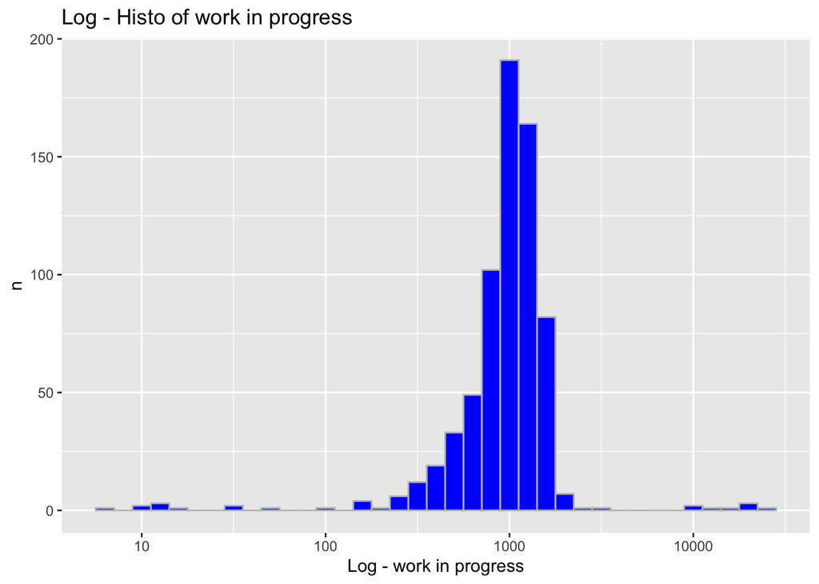

```r
library(ggplot2)

ggplot(data, aes(x = work_in_progress)) +
  geom_histogram(binwidth = 0.1, fill = "blue", color = "grey") +
  scale_x_log10() +
  labs(title = "Log - Histo of work in progress",
       x = "Log - work in progress",
       y = "n")
```

- After checking for missing values, I found that the work_in_progress variable had 506 out of 1,197 missing observations. Following Dr. Post’s recommendation, I decided to impute the median value for this variable since there are several large outliers. I will explore two modeling approaches: one that includes work_in_progress (with median imputation) and one that excludes it entirely, to evaluate its overall impact on model performance.
- Also I found out that on the website it states that “The actual % of productivity that was delivered by the workers. It ranges from 0-1.” which is false since we have values which max are 1.1204. I will remove those rows. This will give us a total of 1160 obs. of 14/15 variables.

```r
summary(data$actual_productivity)
```

```
##    Min. 1st Qu.  Median    Mean 3rd Qu.    Max.
##  0.2337  0.6503  0.7733  0.7351  0.8503  1.1204
```

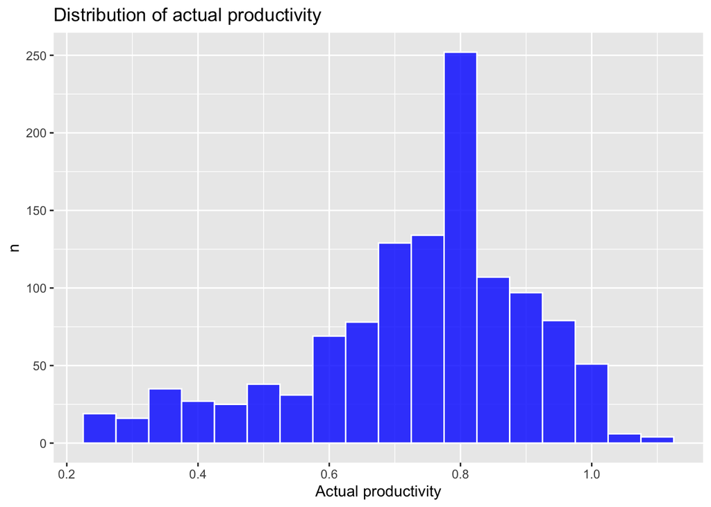

```r
ggplot(data, aes(x = actual_productivity)) +
  geom_histogram(binwidth = 0.05, fill = "blue", color = "white", alpha = 0.8) +
  labs(title = "Distribution of actual productivity",
       x = "Actual productivity",
       y = "n")
```

```r
#only counts for the values max 1
data <- data |> filter(actual_productivity <= 1)

#I'm imputing the missing values with the median.
data$work_in_progress[is.na(data$work_in_progress)] <- median(data$work_in_progress, na.rm = TRUE)

#with work in progress variable
data_with_wip <- data

#without work in progress variable
data_without_wip <- data |> select(-work_in_progress)
```

### Split the Data into a Train and Test Set

```r
library(caret)
set.seed(88)

#with work in progress variable
split_wip <- createDataPartition(data_with_wip$actual_productivity, p = 0.7, list = FALSE)
train_wip <- data_with_wip[split_wip, ]
test_wip  <- data_with_wip[-split_wip, ]

#without work in progress variable
split_nowip <- createDataPartition(data_without_wip$actual_productivity, p = 0.7, list = FALSE)
train_nowip <- data_without_wip[split_nowip, ]
test_nowip  <- data_without_wip[-split_nowip, ]
```

### Training Models (I’m guiding myself by the rubric, questions and then fit the model)

**kNN**

1. Is the model parametric or non-parametric? kNN is a non-parametric model.
2. Does it have tuning parameters? if so, what are they? Yes - k is the tuning parameter.
3. Can we use the model for inference? No - kNN is not interpretable. The model makes predictions based on proximity to training points.
4. Does the model perform variable selection? No - kNN uses all predictors.
5. Do we need to standardize the predictors? Yes - kNN is based on the euclidean distance calculation, so all predictors must be on the same scale.

```r
set.seed(88)

knn_model_wip <- train(
  actual_productivity ~ .,
  data = train_wip,
  method = "knn",
  trControl = trainControl(method = "cv", number = 5),
  preProcess = c("center", "scale"),
  tuneLength = 10
)

pred_knn_wip <- predict(knn_model_wip, test_wip)

cat(" kNN with work in progress:\n")
```

```
##  kNN with work in progress:
```

```r
print(postResample(pred_knn_wip, test_wip$actual_productivity))
```

```
##      RMSE  Rsquared       MAE
## 0.1623462 0.0243449 0.1277319
```

```r
knn_wip_results <- postResample(pred_knn_wip, test_wip$actual_productivity)
```

```r
set.seed(88)

knn_model_nowip <- train(
  actual_productivity ~ .,
  data = train_nowip,
  method = "knn",
  trControl = trainControl(method = "cv", number = 5),
  preProcess = c("center", "scale"),
  tuneLength = 10
)

pred_knn_nowip <- predict(knn_model_nowip, test_nowip)

cat("\n kNN without work in progress:\n")
```

```
##
##  kNN without work in progress:
```

```r
print(postResample(pred_knn_nowip, test_nowip$actual_productivity))
```

```
##       RMSE   Rsquared        MAE
## 0.16196141 0.03212638 0.12553479
```

```r
knn_nowip_results <- postResample(pred_knn_nowip, test_nowip$actual_productivity)
```

- Training the two kNN models, the model without work in progress had a lower RMSE and MAE, and a higher R^2. Which means the variable doesn’t significantly increase performance. So removing work in progress simplifies the model without sacrificing predictive performance.

**(Regularized) Linear Regression - Lasso**

1. Is the model parametric or non-parametric? Lasso is a parametric model.
2. Does it have tuning parameters? if so, what are they? Yes - lambda is the tuning parameter also called penalty.
3. Can we use the model for inference? Yes - Lasso’s coefficients are interpretable.
4. Does the model perform variable selection? Yes - Lasso can shrink coefficients to zero, effectively performing variable selection.
5. Do we need to standardize the predictors? Yes because regularization is sensitive to scale, so standardization is essential.

```r
library(glmnet)
x_wip <- model.matrix(actual_productivity ~ ., train_wip)[, -1]
y_wip <- train_wip$actual_productivity
x_test_wip <- model.matrix(actual_productivity ~ ., test_wip)[, -1]

set.seed(88)
lasso_wip <- cv.glmnet(x_wip, y_wip, alpha = 1, standardize = TRUE)

lasso_wip$lambda.min
```

```
## [1] 0.003189694
```

```r
pred_lasso_wip <- predict(lasso_wip, s = lasso_wip$lambda.min, newx = x_test_wip)

cat(" Lasso with work in progress:\n")
```

```
##  Lasso with work in progress:
```

```r
print(postResample(pred_lasso_wip, test_wip$actual_productivity))
```

```
##      RMSE  Rsquared       MAE
## 0.1399666 0.2673512 0.1001069
```

```r
lasso_wip_results <- postResample(pred_lasso_wip, test_wip$actual_productivity)
```

```r
x_nowip <- model.matrix(actual_productivity ~ ., train_nowip)[, -1]
y_nowip <- train_nowip$actual_productivity
x_test_nowip <- model.matrix(actual_productivity ~ ., test_nowip)[, -1]

set.seed(88)
lasso_nowip <- cv.glmnet(x_nowip, y_nowip, alpha = 1, standardize = TRUE)

lasso_nowip$lambda.min
```

```
## [1] 0.00245987
```

```r
pred_lasso_nowip <- predict(lasso_nowip, s = lasso_nowip$lambda.min, newx = x_test_nowip)

cat("\n Lasso without work in progress:\n")
```

```
##
##  Lasso without work in progress:
```

```r
print(postResample(pred_lasso_nowip, test_nowip$actual_productivity))
```

```
##      RMSE  Rsquared       MAE
## 0.1481270 0.1984704 0.1056343
```

```r
lasso_nowip_results <- postResample(pred_lasso_nowip , test_nowip$actual_productivity)
```

- The lasso model performs better with the model with the variable work in progress. Since it got lower RMSE and MAE and higher R^2.

**GAM with splines**

1. Is the model parametric or non-parametric? GAMs are non-parametric models.
2. Does it have tuning parameters? if so, what are they? Yes they use smoothing parameters to control the trade-off between flexibility and smoothness.
3. Can we use the model for inference? Yes because it provides coefficient estimates and CI for example.
4. Does the model perform variable selection? It uses all the variables but for example in my case, I applied splines only to a few variables that showed more complex behavior, while using others as linear terms.
5. Do we need to standardize the predictors? No because it handles the different scales automatically when using splines.

```r
library(mgcv)
set.seed(88)

#gam with splines with work in progress
gam_wip <- gam(actual_productivity ~
                 s(targeted_productivity, k = 4) +
                 s(no_of_workers, k = 4) +
                 s(work_in_progress, k = 4) +
                 incentive + overtime_minutes + standard_minute_value +
                 idle_time_minutes + idle_workers + no_of_style_change +
                 department + day + quarter,
               data = train_wip)

pred_gam_wip <- predict(gam_wip, newdata = test_wip)

cat(" GAM with work in progress:\n")
```

```
##  GAM with work in progress:
```

```r
print(postResample(pred_gam_wip, test_wip$actual_productivity))
```

```
##       RMSE   Rsquared        MAE
## 0.13946127 0.27558623 0.09839451
```

```r
gam_wip_results <-postResample(pred_gam_wip , test_wip$actual_productivity)
```

```r
set.seed(88)

#gam with splines without work in progress
gam_nowip <- gam(actual_productivity ~
                   s(targeted_productivity, k = 4) +
                   s(no_of_workers, k = 4) +
                   incentive + overtime_minutes + standard_minute_value +
                   idle_time_minutes + idle_workers + no_of_style_change +
                   department + day + quarter,
                 data = train_nowip)

pred_gam_nowip <- predict(gam_nowip, newdata = test_nowip)

cat("\n GAM without work in progress:\n")
```

```
##
##  GAM without work in progress:
```

```r
print(postResample(pred_gam_nowip, test_nowip$actual_productivity))
```

```
##       RMSE   Rsquared        MAE
## 0.14289602 0.25513297 0.09922799
```

```r
gam_nowip_results <-postResample(pred_gam_nowip , test_nowip$actual_productivity)
```

- The GAM model that included the work in progress variable performed better than the one without it (lower RMSE, higher R², and similar MAE). This suggests that the model was able to capture a smooth, non-linear effect of work in progress on productivity.

**Single tree models - Pruned tree**

1. Is the model parametric or non-parametric? They are non-parametric.
2. Does it have tuning parameters? if so, what are they? Yes and the main tuning parameter is the complexity parameter (cp).
3. Can we use the model for inference? No, they are simple to understand and easy to interpret output.
4. Does the model perform variable selection? Yes it automatically selects important variables by choosing the best splits at each node.
5. Do we need to standardize the predictors? No, predictors don’t need to be scaled.

```r
library(rpart)
library(rpart.plot)
set.seed(88)

tree_wip <- rpart(actual_productivity ~ .,
                  data = train_wip,
                  method = "anova",
                  control = rpart.control(cp = 0, xval = 10))

best_cp <- tree_wip$cptable[which.min(tree_wip$cptable[, "xerror"]), "CP"]
pruned_tree_wip <- prune(tree_wip, cp = best_cp)

pred_tree_wip <- predict(pruned_tree_wip, newdata = test_wip)

cat("Pruned tree with work in progress:\n")
```

```
## Pruned tree with work in progress:
```

```r
print(postResample(pred_tree_wip, test_wip$actual_productivity))
```

```
##      RMSE  Rsquared       MAE
## 0.1465663 0.2655209 0.1035520
```

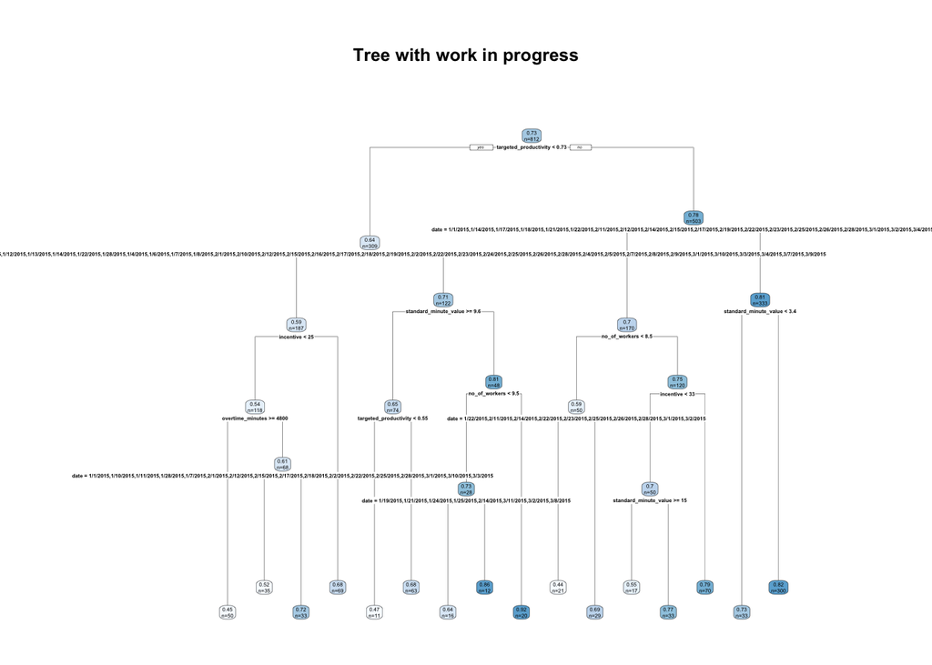

```r
rpart.plot(pruned_tree_wip, main = "Tree with work in progress", type = 2, extra = 1)
```

```r
tree_wip_results <- postResample(pred_tree_wip, test_wip$actual_productivity)
```

```r
set.seed(88)

tree_nowip <- rpart(actual_productivity ~ .,
                    data = train_nowip,
                    method = "anova",
                    control = rpart.control(cp = 0, xval = 10))

best_cp_nowip <- tree_nowip$cptable[which.min(tree_nowip$cptable[, "xerror"]), "CP"]
pruned_tree_nowip <- prune(tree_nowip, cp = best_cp_nowip)

pred_tree_nowip <- predict(pruned_tree_nowip, newdata = test_nowip)

cat("\n Pruned tree without work in progress:\n")
```

```
##
##  Pruned tree without work in progress:
```

```r
print(postResample(pred_tree_nowip, test_nowip$actual_productivity))
```

```
##      RMSE  Rsquared       MAE
## 0.1608720 0.1923768 0.1078598
```

```
## Warning: labs do not fit even at cex 0.15, there may be some overplotting
```

[figure not shown]

```r
rpart.plot(pruned_tree_nowip, main = "Tree without work in progress", type = 2, extra = 1)
```

```r
tree_nowip_results <- postResample(pred_tree_nowip, test_nowip$actual_productivity)
```

- I got an warning on my second tree for the tree without work in progress that may be some overplotting. I pruned the trees by using cp that minimized CV error. The model having the work in progress outperformed the one without work in progress (RMSE = 0.147 vs 0.161). So the tree with the work in progress variable is better to predictive performance and interpretability.

**Ensemble tree models - Random forest**

1. Is the model parametric or non-parametric? Random forest is non-parametric model.
2. Does it have tuning parameters? if so, what are they? Yes, the main tuning parameter is mtry which is the number of predictors to consider at each split.
3. Can we use the model for inference? No which is a major disadvantage of bagging is that the resulting model is often difficult or impossible to interpret, as we are averaging many trees rather than looking at a single tree.
4. Does the model perform variable selection? Yes by using onlt the most informative features from the trees.
5. Do we need to standardize the predictors? No because random forest is not affected by the scale of predictors.

```r
set.seed(88)

random_forest_wip <- train(actual_productivity ~ .,
                method = "rf",
                data = train_wip,
                tuneGrid = data.frame(mtry = 1:(ncol(train_wip) - 1)),
                trControl = trainControl(method = "oob"))

pred_random_forest_wip <- predict(random_forest_wip, newdata = test_wip)

cat(" Random forest with work in progress:\n")
```

```
##  Random forest with work in progress:
```

```r
print(postResample(pred_random_forest_wip, test_wip$actual_productivity))
```

```
##       RMSE   Rsquared        MAE
## 0.11801301 0.47939156 0.07470886
```

```r
cat("\n Mtry:", random_forest_wip$bestTune$mtry, "\n")
```

```
##
##  Mtry: 14
```

```r
random_forest_wip_results <- postResample(pred_random_forest_wip, test_wip$actual_productivity)
```

```r
set.seed(88)

random_forest_nowip <- train(actual_productivity ~ .,
                  method = "rf",
                  data = train_nowip,
                  tuneGrid = data.frame(mtry = 1:(ncol(train_nowip) - 1)),
                  trControl = trainControl(method = "oob"))

pred_random_forest_nowip <- predict(random_forest_nowip, newdata = test_nowip)

cat("\n Random forest without work in progress:\n")
```

```
##
##  Random forest without work in progress:
```

```r
print(postResample(pred_random_forest_nowip, test_nowip$actual_productivity))
```

```
##       RMSE   Rsquared        MAE
## 0.11548538 0.51328414 0.07484676
```

```r
cat("\n Mtry:", random_forest_nowip$bestTune$mtry, "\n")
```

```
##
##  Mtry: 13
```

```r
random_forest_nowip_results <- postResample(pred_random_forest_nowip, test_nowip$actual_productivity)
```

**Support vector machines (SVM) - Regression**

1. Is the model parametric or non-parametric? The SVM is a family of classification rules that contain both parametric such as linear and nonparametric such as kernel based methods.
2. Does it have tuning parameters? if so, what are they? Yes and the main tuning parameters used are the cost, epsilon and kernel for the regression since that is what I am using.
3. Can we use the model for inference? No because they re designed for prediction.
4. Does the model perform variable selection? No, SVMs itself don’t perfom variable selection.
5. Do we need to standardize the predictors? Yes since SVMs are sensitive to the scale of predictions, the svm function from the library e1071 that I used, does it automatically.

```r
library(e1071)
set.seed(88)

svm_wip <- svm(actual_productivity ~ .,
               data = train_wip,
               type = "eps-regression",
               kernel = "linear",
               cost = 1,
               epsilon = 0.1)

pred_svm_wip <- predict(svm_wip, newdata = test_wip)

cat("SVM regression with work in progress:\n")
```

```
## SVM regression with work in progress:
```

```r
print(postResample(pred_svm_wip, test_wip$actual_productivity))
```

```
##      RMSE  Rsquared       MAE
## 0.1422323 0.2822332 0.0947221
```

```r
svm_wip_results <- postResample(pred_svm_wip, test_wip$actual_productivity)
```

```r
set.seed(88)

svm_nowip <- svm(actual_productivity ~ .,
                 data = train_nowip,
                 type = "eps-regression",
                 kernel = "linear",
                 cost = 1,
                 epsilon = 0.1)

pred_svm_nowip <- predict(svm_nowip, newdata = test_nowip)

cat("\n SVM regression without work in progress:\n")
```

```
##
##  SVM regression without work in progress:
```

```r
print(postResample(pred_svm_nowip, test_nowip$actual_productivity))
```

```
##       RMSE   Rsquared        MAE
## 0.14951377 0.23084549 0.09672841
```

```r
svm_nowip_results <- postResample(pred_svm_nowip, test_nowip$actual_productivity)
```

- The SVM regression model performed better with the work in progress variable than without it, showing a lower RMSE and a higher R^2. This means that the SVM capture more of the variance in productivity with the variable work in progress. I used the same cost = 1 and epsilon = 0.1 as in the lecture notes.

**Summary for the training and testing models with and without work in progress**

```r
library(tibble)
library(DT)
library(dplyr)

model_comparison <- tibble::tibble(
  Model = c("kNN (WIP)", "kNN (No WIP)",
            "Lasso (WIP)", "Lasso (No WIP)",
            "GAM (WIP)", "GAM (No WIP)",
            "Tree (WIP)", "Tree (No WIP)",
            "Random forest (WIP)", "Random forest (No WIP)",
            "SVM (WIP)", "SVM (No WIP)"),
  RMSE = c(knn_wip_results["RMSE"], knn_nowip_results["RMSE"],
           lasso_wip_results["RMSE"], lasso_nowip_results["RMSE"],
           gam_wip_results["RMSE"], gam_nowip_results["RMSE"],
           tree_wip_results["RMSE"], tree_nowip_results["RMSE"],
           random_forest_wip_results["RMSE"], random_forest_nowip_results["RMSE"],
           svm_wip_results["RMSE"], svm_nowip_results["RMSE"]),
  Rsquared = c(knn_wip_results["Rsquared"], knn_nowip_results["Rsquared"],
               lasso_wip_results["Rsquared"], lasso_nowip_results["Rsquared"],
               gam_wip_results["Rsquared"], gam_nowip_results["Rsquared"],
               tree_wip_results["Rsquared"], tree_nowip_results["Rsquared"],
               random_forest_wip_results["Rsquared"], random_forest_nowip_results["Rsquared"],
               svm_wip_results["Rsquared"], svm_nowip_results["Rsquared"]),
  MAE = c(knn_wip_results["MAE"], knn_nowip_results["MAE"],
          lasso_wip_results["MAE"], lasso_nowip_results["MAE"],
          gam_wip_results["MAE"], gam_nowip_results["MAE"],
          tree_wip_results["MAE"], tree_nowip_results["MAE"],
          random_forest_wip_results["MAE"], random_forest_nowip_results["MAE"],
          svm_wip_results["MAE"], svm_nowip_results["MAE"])
)

model_comparison <- model_comparison |>
  mutate(RMSE = round(RMSE, 4), Rsquared = round(Rsquared, 4), MAE = round(MAE, 4))

best_rmse <- min(model_comparison$RMSE)
best_rsquared <- max(model_comparison$Rsquared)
best_mae <- min(model_comparison$MAE)

datatable(model_comparison, options = list(pageLength = 15))|>
  formatStyle('RMSE', backgroundColor = styleEqual(best_rmse, 'green'))|>
  formatStyle('Rsquared', backgroundColor = styleEqual(best_rsquared, 'green'))|>
  formatStyle('MAE',backgroundColor = styleEqual(best_mae, 'green'))
```

|  | Model | RMSE | Rsquared | MAE |
| --- | --- | --- | --- | --- |
| 1 | kNN (WIP) | 0.1623 | 0.0243 | 0.1277 |
| 2 | kNN (No WIP) | 0.162 | 0.0321 | 0.1255 |
| 3 | Lasso (WIP) | 0.14 | 0.2674 | 0.1001 |
| 4 | Lasso (No WIP) | 0.1481 | 0.1985 | 0.1056 |
| 5 | GAM (WIP) | 0.1395 | 0.2756 | 0.0984 |
| 6 | GAM (No WIP) | 0.1429 | 0.2551 | 0.0992 |
| 7 | Tree (WIP) | 0.1466 | 0.2655 | 0.1036 |
| 8 | Tree (No WIP) | 0.1609 | 0.1924 | 0.1079 |
| 9 | Random forest (WIP) | 0.118 | 0.4794 | 0.0747 |
| 10 | Random forest (No WIP) | 0.1155 | 0.5133 | 0.0748 |

[output cut: 2 more lines]

**Fitting the best model in the entire dataset**

```r
set.seed(88)

best_model <- train(actual_productivity ~ .,
                        method = "rf",
                        data = data_without_wip,
                        tuneGrid = data.frame(mtry = random_forest_nowip$bestTune$mtry),
                        trControl = trainControl(method = "oob"))

best_pred <- predict(best_model, newdata = data_without_wip)

cat("Best model (random forest without work in progress):\n")
```

```
## Best model (random forest without work in progress):
```

```r
print(postResample(best_pred, data_without_wip$actual_productivity))
```

```
##       RMSE   Rsquared        MAE
## 0.06666647 0.88167333 0.04241605
```

```r
varImp(random_forest_nowip)
```

```
## rf variable importance
##
##   only 20 most important variables shown (out of 78)
##
##                       Overall
## targeted_productivity 100.000
## incentive              71.897
## no_of_workers          62.161
## standard_minute_value  59.715
## team                   48.897
## overtime_minutes       47.207
## departmentfinishing    16.081
## idle_workers           12.624
## departmentsweing       11.193
## idle_time_minutes       9.862
## no_of_style_change      9.657
## quarterQuarter4         7.577
## quarterQuarter3         6.462
## dayThursday             6.174
## date2/2/2015            6.121
## date2/9/2015            6.104
## quarterQuarter2         5.839
## daySunday               5.785
## date2/26/2015           5.640
## dayWednesday            5.370
```

- I identified the most influential variables in the best model, using the varImp function. The top predictors of employee productivity were targeted_productivity, incentive, no_of_workers, standard_minute_value, team and overtime_minutes. These features had the highest variable importance scores, indicating that they contributed the most to accurate predictions. The function by default only shows the 20 most important variables but there are in total 78 variables.

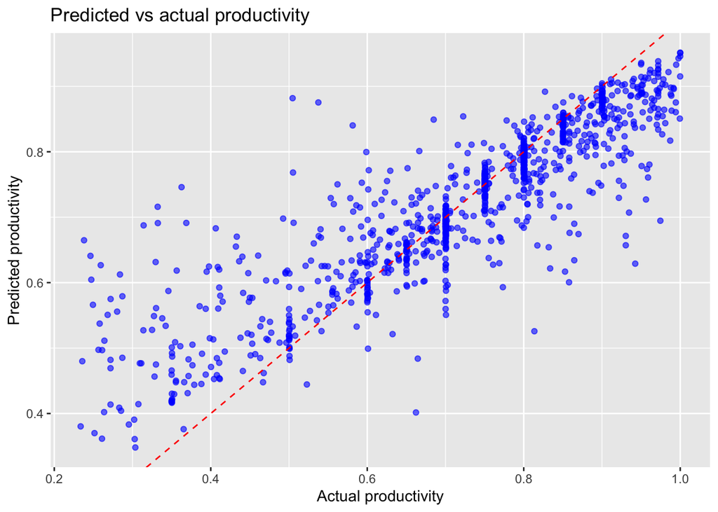

```r
ggplot(data_without_wip, aes(x = actual_productivity, y = predict(random_forest_nowip, newdata = data_without_wip))) +
  geom_point(alpha = 0.6, color = "blue") +
  geom_abline(slope = 1, intercept = 0, linetype = "dashed", color = "red") +
  labs(
    title = "Predicted vs actual productivity",
    x = "Actual productivity",
    y = "Predicted productivity"
  )
```